# Project 5 - Travel Package Purchase Prediction

**Brandy Murray**

# Context:

You are a Data Scientist for a tourism company named "Visit with Us". The Policy Maker of the company wants to enable and establish a viable business model to expand the customer base.

A viable business model is a central concept that helps you to understand the existing ways of doing the business and how to change the ways for the benefit of the tourism sector.

One of the ways to expand the customer base is to introduce a new offering of packages.

Currently, there are 5 types of packages the company is offering - Basic, Standard, Deluxe, Super Deluxe, King. Looking at the data of the last year, we observed that 18% of the customers purchased the packages.

# Problem Statement:

The company in the last campaign contacted the customers at random without looking at the available information. However, this time company is now planning to launch a new product i.e. Wellness Tourism Package. Wellness Tourism is defined as Travel that allows the traveler to maintain, enhance or kick-start a healthy lifestyle, and support or increase one's sense of well-being, and wants to harness the available data of existing and potential customers to make the marketing expenditure more efficient.

You as a Data Scientist at "Visit with Us" travel company has to analyze the customers' data and information to provide recommendations to the Policy Maker and Marketing Team and also build a model to predict the potential customer who is going to purchase the newly introduced travel package.

# Objective:

To predict which customer is more likely to purchase the newly introduced travel package.

**Data Dictionary** **Tourism**

- CustomerID: Unique customer ID
- ProdTaken: Whether the customer has purchased a package or not (0: No, 1: Yes)
- Age: Age of customer
- TypeofContact: How customer was contacted (Company Invited or Self Inquiry)
- CityTier: City tier depends on the development of a city, population, facilities, and living standards. The categories are ordered i.e. Tier 1 > Tier 2 > Tier 3
- DurationOfPitch: Duration of the pitch by a salesperson to the customer
- Occupation: Occupation of customer
- Gender: Gender of customer
- NumberOfPersonVisiting: Total number of persons planning to take the trip with the customer
- NumberOfFollowups: Total number of follow-ups has been done by sales person after sales pitch
- ProductPitched: Product pitched by the salesperson
- PreferredPropertyStar: Preferred hotel property rating by customer
- MaritalStatus: Marital status of customer
- NumberOfTrips: Average number of trips in a year by customer
- Passport: The customer has a passport or not (0: No, 1: Yes)
- PitchSatisfactionScore: Sales pitch satisfaction score
- OwnCar: Whether the customers own a car or not (0: No, 1: Yes)
- NumberOfChildrenVisiting: Total number of children with age less than 5 planning to take the trip with the customer
- Designation: Designation of the customer in the current organization
- MonthlyIncome: Gross monthly income of the customer

**Importing the libraries we need.**

```python
# This will help in making the Python code more structured automatically (good coding practice)
%load_ext nb_black

# Import warnings
import warnings

warnings.filterwarnings("ignore")

# Libraries to help with reading and manipulating data
import pandas as pd
import numpy as np
import statistics as stats

# Libraries to help with data visualizations
import matplotlib.pyplot as plt
%matplotlib inline
import seaborn as sns

# Libraries for Bagging Classifier and Random Forest Classifier
from sklearn.model_selection import train_test_split
from sklearn.model_selection import GridSearchCV
from sklearn import metrics
from sklearn.ensemble import BaggingClassifier, RandomForestClassifier
from sklearn.linear_model import LogisticRegression

# Additional Libraries for AdaBoost Classifier, Gradient Boosting Classifier and XGBoost Classifier
from sklearn.tree import DecisionTreeClassifier
from sklearn.ensemble import AdaBoostClassifier, GradientBoostingClassifier
#To install xgboost library use - !pip install xgboost
from xgboost import XGBClassifier

# Remove the limit for the number of displayed columns
pd.set_option("display.max_columns", None)
# Sets the limit for the number of displayed rows
pd.set_option("display.max_rows", 200)
```

```
The nb_black extension is already loaded. To reload it, use:
  %reload_ext nb_black
```

```python
# Loading the dataset
tourism = pd.read_excel("Tourism.xlsx", sheet_name="Tourism")
```

```python
# Creating a copy of the original file
df = tourism.copy()
```

```python
# Printing the shape of the data in an f-string
print(f"There are {df.shape[0]} rows and {df.shape[1]} columns.")
```

```
There are 4888 rows and 20 columns.
```

```python
# This shows the first 5 rows of data
df.head()
```

|  | CustomerID | ProdTaken | Age | TypeofContact | CityTier | DurationOfPitch | Occupation | Gender | NumberOfPersonVisiting | NumberOfFollowups | ProductPitched | PreferredPropertyStar | MaritalStatus | NumberOfTrips | Passport | PitchSatisfactionScore | OwnCar | NumberOfChildrenVisiting | Designation | MonthlyIncome |
| --- | --- | --- | --- | --- | --- | --- | --- | --- | --- | --- | --- | --- | --- | --- | --- | --- | --- | --- | --- | --- |
| 0 | 200000 | 1 | 41.0 | Self Enquiry | 3 | 6.0 | Salaried | Female | 3 | 3.0 | Deluxe | 3.0 | Single | 1.0 | 1 | 2 | 1 | 0.0 | Manager | 20993.0 |
| 1 | 200001 | 0 | 49.0 | Company Invited | 1 | 14.0 | Salaried | Male | 3 | 4.0 | Deluxe | 4.0 | Divorced | 2.0 | 0 | 3 | 1 | 2.0 | Manager | 20130.0 |
| 2 | 200002 | 1 | 37.0 | Self Enquiry | 1 | 8.0 | Free Lancer | Male | 3 | 4.0 | Basic | 3.0 | Single | 7.0 | 1 | 3 | 0 | 0.0 | Executive | 17090.0 |
| 3 | 200003 | 0 | 33.0 | Company Invited | 1 | 9.0 | Salaried | Female | 2 | 3.0 | Basic | 3.0 | Divorced | 2.0 | 1 | 5 | 1 | 1.0 | Executive | 17909.0 |
| 4 | 200004 | 0 | NaN | Self Enquiry | 1 | 8.0 | Small Business | Male | 2 | 3.0 | Basic | 4.0 | Divorced | 1.0 | 0 | 5 | 1 | 0.0 | Executive | 18468.0 |

```python
# I'm now going to look at 10 random rows
# I like to change the random seed number a few times to get a good look at the data
np.random.seed(6)
df.sample(n=10)
```

|  | CustomerID | ProdTaken | Age | TypeofContact | CityTier | DurationOfPitch | Occupation | Gender | NumberOfPersonVisiting | NumberOfFollowups | ProductPitched | PreferredPropertyStar | MaritalStatus | NumberOfTrips | Passport | PitchSatisfactionScore | OwnCar | NumberOfChildrenVisiting | Designation | MonthlyIncome |
| --- | --- | --- | --- | --- | --- | --- | --- | --- | --- | --- | --- | --- | --- | --- | --- | --- | --- | --- | --- | --- |
| 3713 | 203713 | 0 | 44.0 | Self Enquiry | 2 | 9.0 | Salaried | Male | 4 | 4.0 | Basic | 3.0 | Unmarried | 2.0 | 0 | 1 | 0 | 1.0 | Executive | 22217.0 |
| 3688 | 203688 | 0 | 31.0 | Company Invited | 1 | 9.0 | Large Business | Fe Male | 4 | 5.0 | Basic | 5.0 | Unmarried | 2.0 | 0 | 3 | 0 | 2.0 | Executive | 23646.0 |
| 1546 | 201546 | 0 | 35.0 | Self Enquiry | 3 | NaN | Small Business | Male | 2 | 4.0 | Deluxe | 5.0 | Single | 1.0 | 0 | 1 | 1 | 1.0 | Manager | NaN |
| 1565 | 201565 | 0 | 54.0 | Self Enquiry | 1 | 8.0 | Large Business | Female | 2 | 3.0 | Standard | 3.0 | Married | 1.0 | 0 | 4 | 0 | 0.0 | Senior Manager | 28549.0 |
| 2976 | 202976 | 0 | 48.0 | Self Enquiry | 3 | 21.0 | Small Business | Male | 3 | 4.0 | Deluxe | 5.0 | Unmarried | 4.0 | 0 | 2 | 0 | 2.0 | Manager | 23638.0 |
| 2422 | 202422 | 1 | 31.0 | Self Enquiry | 3 | 19.0 | Small Business | Male | 3 | 4.0 | Deluxe | 5.0 | Married | 6.0 | 1 | 1 | 1 | 0.0 | Manager | 17302.0 |
| 1372 | 201372 | 0 | 39.0 | Self Enquiry | 1 | 15.0 | Small Business | Male | 2 | 3.0 | Deluxe | 5.0 | Married | 2.0 | 0 | 4 | 1 | 0.0 | Manager | 20151.0 |
| 2139 | 202139 | 1 | 39.0 | Self Enquiry | 1 | 12.0 | Small Business | Male | 3 | 3.0 | Basic | 5.0 | Married | 1.0 | 1 | 1 | 1 | 1.0 | Executive | 17404.0 |
| 2062 | 202062 | 0 | 47.0 | Self Enquiry | 1 | 8.0 | Salaried | Female | 2 | 3.0 | Super Deluxe | 3.0 | Married | 2.0 | 1 | 4 | 1 | 0.0 | AVP | 31752.0 |
| 996 | 200996 | 0 | 27.0 | Self Enquiry | 3 | 16.0 | Small Business | Female | 3 | 4.0 | Deluxe | 3.0 | Divorced | 2.0 | 1 | 3 | 1 | 2.0 | Manager | 20769.0 |

```python
# This shows the last 5 rows of the data
df.tail(10)
```

|  | CustomerID | ProdTaken | Age | TypeofContact | CityTier | DurationOfPitch | Occupation | Gender | NumberOfPersonVisiting | NumberOfFollowups | ProductPitched | PreferredPropertyStar | MaritalStatus | NumberOfTrips | Passport | PitchSatisfactionScore | OwnCar | NumberOfChildrenVisiting | Designation | MonthlyIncome |
| --- | --- | --- | --- | --- | --- | --- | --- | --- | --- | --- | --- | --- | --- | --- | --- | --- | --- | --- | --- | --- |
| 4878 | 204878 | 1 | 35.0 | Self Enquiry | 1 | 17.0 | Small Business | Male | 3 | 4.0 | Deluxe | 5.0 | Unmarried | 3.0 | 0 | 4 | 0 | 1.0 | Manager | 24803.0 |
| 4879 | 204879 | 1 | 26.0 | Self Enquiry | 2 | 27.0 | Small Business | Female | 4 | 4.0 | Basic | 4.0 | Married | 2.0 | 1 | 3 | 0 | 2.0 | Executive | 22347.0 |
| 4880 | 204880 | 1 | 59.0 | Self Enquiry | 1 | 28.0 | Small Business | Female | 4 | 4.0 | Deluxe | 4.0 | Married | 6.0 | 0 | 3 | 1 | 2.0 | Manager | 28686.0 |
| 4881 | 204881 | 1 | 41.0 | Self Enquiry | 2 | 25.0 | Salaried | Male | 3 | 2.0 | Basic | 5.0 | Married | 2.0 | 0 | 1 | 1 | 2.0 | Executive | 21065.0 |
| 4882 | 204882 | 1 | 37.0 | Self Enquiry | 2 | 20.0 | Salaried | Male | 3 | 5.0 | Basic | 5.0 | Married | 6.0 | 1 | 5 | 1 | 2.0 | Executive | 23317.0 |
| 4883 | 204883 | 1 | 49.0 | Self Enquiry | 3 | 9.0 | Small Business | Male | 3 | 5.0 | Deluxe | 4.0 | Unmarried | 2.0 | 1 | 1 | 1 | 1.0 | Manager | 26576.0 |
| 4884 | 204884 | 1 | 28.0 | Company Invited | 1 | 31.0 | Salaried | Male | 4 | 5.0 | Basic | 3.0 | Single | 3.0 | 1 | 3 | 1 | 2.0 | Executive | 21212.0 |
| 4885 | 204885 | 1 | 52.0 | Self Enquiry | 3 | 17.0 | Salaried | Female | 4 | 4.0 | Standard | 4.0 | Married | 7.0 | 0 | 1 | 1 | 3.0 | Senior Manager | 31820.0 |
| 4886 | 204886 | 1 | 19.0 | Self Enquiry | 3 | 16.0 | Small Business | Male | 3 | 4.0 | Basic | 3.0 | Single | 3.0 | 0 | 5 | 0 | 2.0 | Executive | 20289.0 |
| 4887 | 204887 | 1 | 36.0 | Self Enquiry | 1 | 14.0 | Salaried | Male | 4 | 4.0 | Basic | 4.0 | Unmarried | 3.0 | 1 | 3 | 1 | 2.0 | Executive | 24041.0 |

- After looking at the head, the random rows, and the tail:
  - we can see that the names of the columns are in good shape
  - on `random.seed(6)` I noticed in the `Gender` there was `Female, Male, and Fe Male`. This needs to be fixed.
  - I do not feel we need `CustomerID`. This is just a duplication of the generate ID with a 20 in front.
  - I believe the following columns should be categorical do to their nature:
    1. `TypeofContact`
    2. `CityTier`
    3. `Occupation`
    4. `Gender`
    5. `ProductPitched`
    6. `PreferredPropertyStar`
    7. `MaritalStatus`
    8. `Designation`
  - I will do further investigation of these columns below and change these types when appropriate.

```python
# Dropping CustomerID
df.drop(["CustomerID"], axis=1, inplace=True)
```

```python
# Fixing the Fe Male entries in the Gender column
df["Gender"].replace(["Fe Male"], ["Female"], inplace=True)
```

**Check data types and numbers of non-null values for each column.**

```python
df.info()
```

```
<class 'pandas.core.frame.DataFrame'>
RangeIndex: 4888 entries, 0 to 4887
Data columns (total 19 columns):
 #   Column                    Non-Null Count  Dtype
---  ------                    --------------  -----
 0   ProdTaken                 4888 non-null   int64
 1   Age                       4662 non-null   float64
 2   TypeofContact             4863 non-null   object
 3   CityTier                  4888 non-null   int64
 4   DurationOfPitch           4637 non-null   float64
 5   Occupation                4888 non-null   object
 6   Gender                    4888 non-null   object
 7   NumberOfPersonVisiting    4888 non-null   int64
 8   NumberOfFollowups         4843 non-null   float64
 9   ProductPitched            4888 non-null   object
 10  PreferredPropertyStar     4862 non-null   float64
 11  MaritalStatus             4888 non-null   object
 12  NumberOfTrips             4748 non-null   float64
 13  Passport                  4888 non-null   int64
 14  PitchSatisfactionScore    4888 non-null   int64
 15  OwnCar                    4888 non-null   int64
 16  NumberOfChildrenVisiting  4822 non-null   float64
 17  Designation               4888 non-null   object
 18  MonthlyIncome             4655 non-null   float64
dtypes: float64(7), int64(6), object(6)
memory usage: 725.7+ KB
```

```python
df.dtypes.value_counts()
```

```
float64    7
int64      6
object     6
dtype: int64
```

```python
df.describe().T
```

|  | count | mean | std | min | 25% | 50% | 75% | max |
| --- | --- | --- | --- | --- | --- | --- | --- | --- |
| ProdTaken | 4888.0 | 0.188216 | 0.390925 | 0.0 | 0.0 | 0.0 | 0.0 | 1.0 |
| Age | 4662.0 | 37.622265 | 9.316387 | 18.0 | 31.0 | 36.0 | 44.0 | 61.0 |
| CityTier | 4888.0 | 1.654255 | 0.916583 | 1.0 | 1.0 | 1.0 | 3.0 | 3.0 |
| DurationOfPitch | 4637.0 | 15.490835 | 8.519643 | 5.0 | 9.0 | 13.0 | 20.0 | 127.0 |
| NumberOfPersonVisiting | 4888.0 | 2.905074 | 0.724891 | 1.0 | 2.0 | 3.0 | 3.0 | 5.0 |
| NumberOfFollowups | 4843.0 | 3.708445 | 1.002509 | 1.0 | 3.0 | 4.0 | 4.0 | 6.0 |
| PreferredPropertyStar | 4862.0 | 3.581037 | 0.798009 | 3.0 | 3.0 | 3.0 | 4.0 | 5.0 |
| NumberOfTrips | 4748.0 | 3.236521 | 1.849019 | 1.0 | 2.0 | 3.0 | 4.0 | 22.0 |
| Passport | 4888.0 | 0.290917 | 0.454232 | 0.0 | 0.0 | 0.0 | 1.0 | 1.0 |
| PitchSatisfactionScore | 4888.0 | 3.078151 | 1.365792 | 1.0 | 2.0 | 3.0 | 4.0 | 5.0 |
| OwnCar | 4888.0 | 0.620295 | 0.485363 | 0.0 | 0.0 | 1.0 | 1.0 | 1.0 |
| NumberOfChildrenVisiting | 4822.0 | 1.187267 | 0.857861 | 0.0 | 1.0 | 1.0 | 2.0 | 3.0 |
| MonthlyIncome | 4655.0 | 23619.853491 | 5380.698361 | 1000.0 | 20346.0 | 22347.0 | 25571.0 | 98678.0 |

```python
df.isna().sum()
```

```
ProdTaken                     0
Age                         226
TypeofContact                25
CityTier                      0
DurationOfPitch             251
Occupation                    0
Gender                        0
NumberOfPersonVisiting        0
NumberOfFollowups            45
ProductPitched                0
PreferredPropertyStar        26
MaritalStatus                 0
NumberOfTrips               140
Passport                      0
PitchSatisfactionScore        0
OwnCar                        0
NumberOfChildrenVisiting     66
Designation                   0
MonthlyIncome               233
dtype: int64
```

- Here we can see there are 8 columns that have missing values
  1. `Age`
  2. `TypeofContact`
  3. `DurationOfPitch`
  4. `NumberOfFollowups`
  5. `PreferredPropertyStar`
  6. `NumberOfTrips`
  7. `NumberOfChildrenVisiting`
  8. `MonthlyIncome`

```python
# The first step to taking care of missing values is to separate the data into categorical and numerical groups.
num_vars = df.columns[df.dtypes != "object"]
cat_vars = df.columns[df.dtypes == "object"]

print(num_vars)
print(cat_vars)
```

```
Index(['ProdTaken', 'Age', 'CityTier', 'DurationOfPitch',
       'NumberOfPersonVisiting', 'NumberOfFollowups', 'PreferredPropertyStar',
       'NumberOfTrips', 'Passport', 'PitchSatisfactionScore', 'OwnCar',
       'NumberOfChildrenVisiting', 'MonthlyIncome'],
      dtype='object')
Index(['TypeofContact', 'Occupation', 'Gender', 'ProductPitched',
       'MaritalStatus', 'Designation'],
      dtype='object')
```

```python
# Looking at the number of missing values for the numerical variables
df[num_vars].isnull().sum().sort_values(ascending=False)
```

```
DurationOfPitch             251
MonthlyIncome               233
Age                         226
NumberOfTrips               140
NumberOfChildrenVisiting     66
NumberOfFollowups            45
PreferredPropertyStar        26
OwnCar                        0
PitchSatisfactionScore        0
Passport                      0
NumberOfPersonVisiting        0
CityTier                      0
ProdTaken                     0
dtype: int64
```

```python
num_missing = [
    "DurationOfPitch",
    "MonthlyIncome",
    "Age",
    "NumberOfTrips",
    "NumberOfChildrenVisiting",
    "NumberOfFollowups",
    "PreferredPropertyStar",
]
```

```python
# This shows the percentage of variables that are missing
df[num_missing].isnull().sum().sort_values(ascending=False) / len(df)
```

```
DurationOfPitch             0.051350
MonthlyIncome               0.047668
Age                         0.046236
NumberOfTrips               0.028642
NumberOfChildrenVisiting    0.013502
NumberOfFollowups           0.009206
PreferredPropertyStar       0.005319
dtype: float64
```

- We can see that at the highest only 5% of the variables are missing values. So I am going to look deeper into each column and try to fill the missing values.

```python
# Looking at the num_vars statistics
df[num_missing].describe().T
```

|  | count | mean | std | min | 25% | 50% | 75% | max |
| --- | --- | --- | --- | --- | --- | --- | --- | --- |
| DurationOfPitch | 4637.0 | 15.490835 | 8.519643 | 5.0 | 9.0 | 13.0 | 20.0 | 127.0 |
| MonthlyIncome | 4655.0 | 23619.853491 | 5380.698361 | 1000.0 | 20346.0 | 22347.0 | 25571.0 | 98678.0 |
| Age | 4662.0 | 37.622265 | 9.316387 | 18.0 | 31.0 | 36.0 | 44.0 | 61.0 |
| NumberOfTrips | 4748.0 | 3.236521 | 1.849019 | 1.0 | 2.0 | 3.0 | 4.0 | 22.0 |
| NumberOfChildrenVisiting | 4822.0 | 1.187267 | 0.857861 | 0.0 | 1.0 | 1.0 | 2.0 | 3.0 |
| NumberOfFollowups | 4843.0 | 3.708445 | 1.002509 | 1.0 | 3.0 | 4.0 | 4.0 | 6.0 |
| PreferredPropertyStar | 4862.0 | 3.581037 | 0.798009 | 3.0 | 3.0 | 3.0 | 4.0 | 5.0 |

```python
def histogram_boxplot(data, feature, figsize=(12, 7), kde=False, bins=None):
    """
    Boxplot and histogram combined

    data: dataframe
    feature: dataframe column
    figsize: size of figure (default (12,7))
    kde: whether to show the density curve (default False)
    bins: number of bins for histogram (default None)
    """
    f2, (ax_box2, ax_hist2) = plt.subplots(
        nrows=2,  # Number of rows of the subplot grid= 2
        sharex=True,  # x-axis will be shared among all subplots
        gridspec_kw={"height_ratios": (0.25, 0.75)},
        figsize=figsize,
    )  # creating the 2 subplots
    sns.boxplot(
        data=data, x=feature, ax=ax_box2, showmeans=True, color="violet"
    )  # boxplot will be created and a star will indicate the mean value of the column
    sns.histplot(
        data=data, x=feature, kde=kde, ax=ax_hist2, bins=bins, palette="winter"
    ) if bins else sns.histplot(
        data=data, x=feature, kde=kde, ax=ax_hist2
    )  # For histogram
    ax_hist2.axvline(
        data[feature].mean(), color="green", linestyle="--"
    )  # Add mean to the histogram
    ax_hist2.axvline(
        data[feature].median(), color="black", linestyle="-"
    )  # Add median to the histogram
```

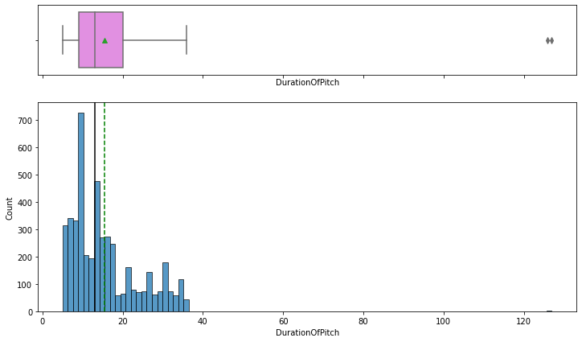

```python
histogram_boxplot(df[num_missing], "DurationOfPitch")
```

```python
stats.mode(df["DurationOfPitch"])
```

```
9.0
```

- Looking at the histplot of `DurationOfPitch` we know that the mean is 15.490835 is not the best central measure to use since the distribution is right skewed.
- Therefore we look at the median of 13.0 and the mode of 9.0.
- While the median is generally used more often for skewed data, I feel in this case the mode is better to use. The numbers are so close that it probably would be fine to use either.

```python
# Row 1546 has a NaN for comparison
display(df["DurationOfPitch"].iloc[1546])
df["DurationOfPitch"] = df["DurationOfPitch"].replace(np.NaN, 9.0)
display(df["DurationOfPitch"].iloc[1546])
```

```
nan
```

```
9.0
```

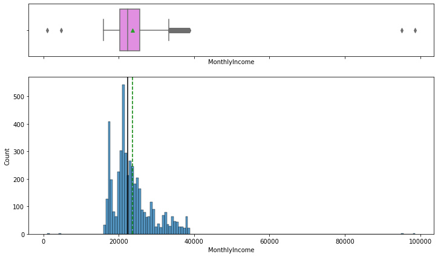

```python
histogram_boxplot(df[num_missing], "MonthlyIncome")
```

```python
stats.mode(df["MonthlyIncome"])
```

```
---------------------------------------------------------------------------
StatisticsError                           Traceback (most recent call last)
<ipython-input-24-55171c9db61c> in <module>
----> 1 stats.mode(df["MonthlyIncome"])

C:\Anaconda\lib\statistics.py in mode(data)
    504     elif table:
    505         raise StatisticsError(
--> 506                 'no unique mode; found %d equally common values' % len(table)
    507                 )
    508     else:

StatisticsError: no unique mode; found 4 equally common values
```

- Looking at the histplot of `MonthlyIncome` we know that the mean is 23619.853491 and the median is 22347.0.
- As we can see from the error above there is not a single common value to create the mode.
- Since the mean and median are so close we can use the mean to fill in the missing values.

```python
# Row 1546 has a NaN for comparison
display(df["MonthlyIncome"].iloc[1546])
df["MonthlyIncome"] = df["MonthlyIncome"].replace(np.NaN, 23619.85)
display(df["MonthlyIncome"].iloc[1546])
```

```
nan
```

```
23619.85
```

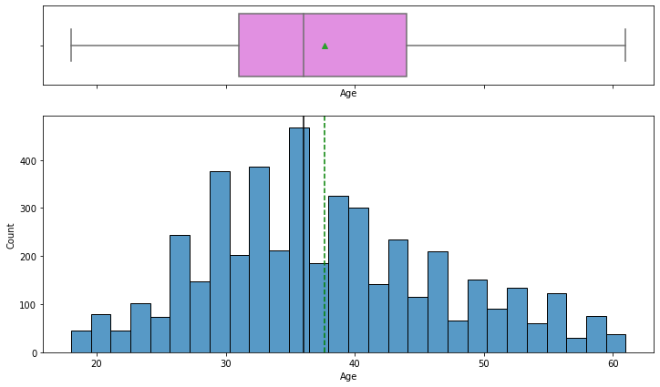

```python
histogram_boxplot(df[num_missing], "Age")
```

```python
stats.mode(df["Age"])
```

```
35.0
```

- Looking at the histplot of `Age` we know that the mean is 37.622265, the median is 36.0 and the mode is 35.0.
- Since the mean, median, and mode are so close we can use the mean to fill in the missing values.

```python
# Row 2394 has a NaN for comparison
display(df["Age"].iloc[2394])
df["Age"] = df["Age"].replace(np.NaN, 37.0)
display(df["Age"].iloc[2394])
```

```
nan
```

```
37.0
```

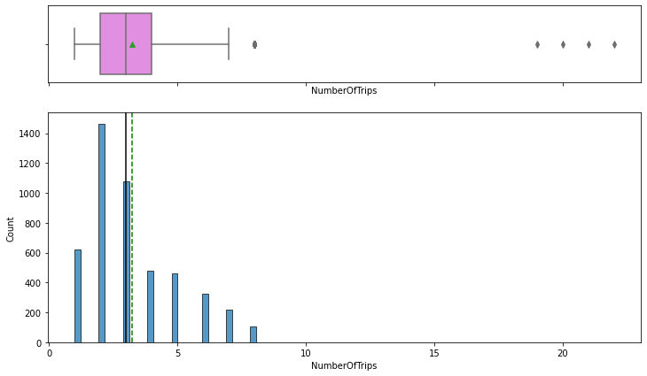

```python
histogram_boxplot(df[num_missing], "NumberOfTrips")
```

```python
stats.mode(df["NumberOfTrips"])
```

```
2.0
```

- Looking at the histplot of `NumberOfTrips` we know that the mean is 3.236521, the median is 3.0 and the mode is 2.0.
- Since the mean and the median are so close we can use the median to fill in the missing values since it is logical to have a whole number.

```python
# Row 2394 has a NaN for comparison
display(df["NumberOfTrips"].iloc[4449])
df["NumberOfTrips"] = df["NumberOfTrips"].replace(np.NaN, 3.0)
display(df["NumberOfTrips"].iloc[4449])
```

```
nan
```

```
3.0
```

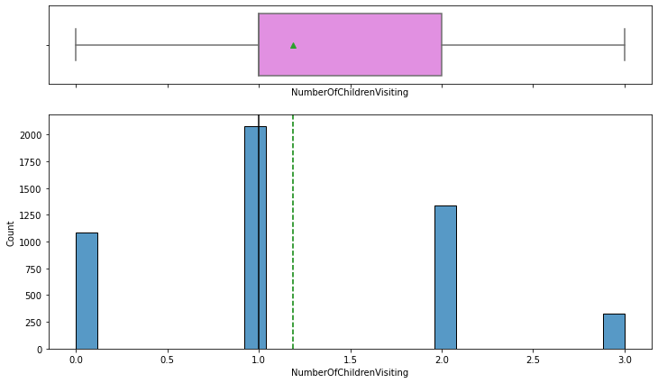

```python
histogram_boxplot(df[num_missing], "NumberOfChildrenVisiting")
```

```python
stats.mode(df["NumberOfChildrenVisiting"])
```

```
1.0
```

- Looking at the histplot of `NumberOfChildrenVisiting` we know that the mean is 1.187267, the median is 1.0 and the mode is 1.0.
- Since the mode and median are both one and it doesn't make sense to have 1.187267 number of children visiting we can replace the missing values with 1.0.

```python
# Row 2394 has a NaN for comparison
display(df["NumberOfChildrenVisiting"].iloc[1242])
df["NumberOfChildrenVisiting"] = df["NumberOfChildrenVisiting"].replace(np.NaN, 1.0)
display(df["NumberOfChildrenVisiting"].iloc[1242])
```

```
nan
```

```
1.0
```

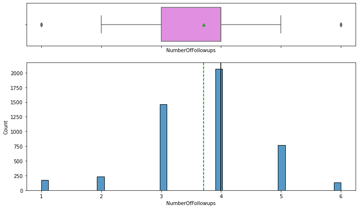

```python
histogram_boxplot(df[num_missing], "NumberOfFollowups")
```

```python
stats.mode(df["NumberOfFollowups"])
```

```
4.0
```

- Looking at the histplot of `NumberOfFollowups` we know that the mean is 3.708445, the median is 4.0 and the mode is 4.0.
- Since the mode and median are both four and it doesn't make sense to have 3.708445 number of followups we can replace the missing values with 4.0.

```python
# Row 2394 has a NaN for comparison
display(df["NumberOfFollowups"].iloc[748])
df["NumberOfFollowups"] = df["NumberOfFollowups"].replace(np.NaN, 4.0)
display(df["NumberOfFollowups"].iloc[748])
```

```
nan
```

```
4.0
```

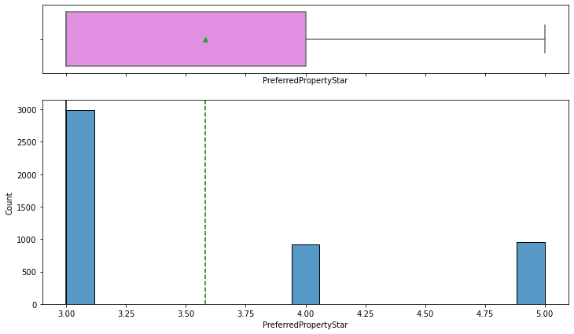

```python
histogram_boxplot(df[num_missing], "PreferredPropertyStar")
```

```python
stats.mode(df["PreferredPropertyStar"])
```

```
3.0
```

- Looking at the histplot of `PreferredPropertyStar` we know that the mean is 3.581037, the median is 3.0 and the mode is 3.0.
- Since the mode and median are both three and this rating system doesn't include fraction of stars for property ratings we can replace the missing values with 3.0.

```python
# Row 2394 has a NaN for comparison
display(df["PreferredPropertyStar"].iloc[4812])
df["PreferredPropertyStar"] = df["PreferredPropertyStar"].replace(np.NaN, 3.0)
display(df["PreferredPropertyStar"].iloc[4812])
```

```
nan
```

```
3.0
```

```python
# Now that the numerical variables are taken care of we can see what is left
df.isna().sum()
```

```
ProdTaken                    0
Age                          0
TypeofContact               25
CityTier                     0
DurationOfPitch              0
Occupation                   0
Gender                       0
NumberOfPersonVisiting       0
NumberOfFollowups            0
ProductPitched               0
PreferredPropertyStar        0
MaritalStatus                0
NumberOfTrips                0
Passport                     0
PitchSatisfactionScore       0
OwnCar                       0
NumberOfChildrenVisiting     0
Designation                  0
MonthlyIncome                0
dtype: int64
```

```python
# Checking the different types of contact and how many are in each
df["TypeofContact"].value_counts()
```

```
Self Enquiry       3444
Company Invited    1419
Name: TypeofContact, dtype: int64
```

- Since there are only 25 missing values, I am going to put them in Self Enquiry.
- If the amount of missing values was greater I would think about finding the percentage the current values make up and filling in the missing values in a similar percentage.

```python
# Row 2394 has a NaN for comparison
display(df["TypeofContact"].iloc[224])
df["TypeofContact"] = df["TypeofContact"].replace(np.NaN, "Self Enquiry")
display(df["TypeofContact"].iloc[224])
```

```
'Self Enquiry'
```

```
'Self Enquiry'
```

```python
# Now that the numerical variables are taken care of we can see what is left
df.isna().sum()
```

```
ProdTaken                   0
Age                         0
TypeofContact               0
CityTier                    0
DurationOfPitch             0
Occupation                  0
Gender                      0
NumberOfPersonVisiting      0
NumberOfFollowups           0
ProductPitched              0
PreferredPropertyStar       0
MaritalStatus               0
NumberOfTrips               0
Passport                    0
PitchSatisfactionScore      0
OwnCar                      0
NumberOfChildrenVisiting    0
Designation                 0
MonthlyIncome               0
dtype: int64
```

**There are no more missing values.**

Now we need to change the object types into categories and consider changing a few of the numerical variables into categories as well.

```python
for feature in df.columns:  # Loop through all columns in the dataframe
    if df[feature].dtype == "object":  # Only apply for columns with categorical strings
        df[feature] = pd.Categorical(df[feature])  # Replace strings with an integer
df.dtypes
```

```
ProdTaken                      int64
Age                          float64
TypeofContact               category
CityTier                       int64
DurationOfPitch              float64
Occupation                  category
Gender                      category
NumberOfPersonVisiting         int64
NumberOfFollowups            float64
ProductPitched              category
PreferredPropertyStar        float64
MaritalStatus               category
NumberOfTrips                float64
Passport                       int64
PitchSatisfactionScore         int64
OwnCar                         int64
NumberOfChildrenVisiting     float64
Designation                 category
MonthlyIncome                float64
dtype: object
```

- After seeing the histoplots for `PreferredPropertyStar` and knowing that `CityTier` is a number scale that is not meant for numerical analysis, I am going to switch these two to a categorical variable.

```python
df["PreferredPropertyStar"] = pd.Categorical(df["PreferredPropertyStar"])
df["CityTier"] = pd.Categorical(df["CityTier"])
```

```python
df.info()
```

```
<class 'pandas.core.frame.DataFrame'>
RangeIndex: 4888 entries, 0 to 4887
Data columns (total 19 columns):
 #   Column                    Non-Null Count  Dtype
---  ------                    --------------  -----
 0   ProdTaken                 4888 non-null   int64
 1   Age                       4888 non-null   float64
 2   TypeofContact             4888 non-null   category
 3   CityTier                  4888 non-null   category
 4   DurationOfPitch           4888 non-null   float64
 5   Occupation                4888 non-null   category
 6   Gender                    4888 non-null   category
 7   NumberOfPersonVisiting    4888 non-null   int64
 8   NumberOfFollowups         4888 non-null   float64
 9   ProductPitched            4888 non-null   category
 10  PreferredPropertyStar     4888 non-null   category
 11  MaritalStatus             4888 non-null   category
 12  NumberOfTrips             4888 non-null   float64
 13  Passport                  4888 non-null   int64
 14  PitchSatisfactionScore    4888 non-null   int64
 15  OwnCar                    4888 non-null   int64
 16  NumberOfChildrenVisiting  4888 non-null   float64
 17  Designation               4888 non-null   category
 18  MonthlyIncome             4888 non-null   float64
dtypes: category(8), float64(6), int64(5)
memory usage: 459.5 KB
```

```python
# This lets us see the number of choices within each variable
print(df.TypeofContact.value_counts())
print(df.CityTier.value_counts())
print(df.Occupation.value_counts())
print(df.Gender.value_counts())
print(df.ProductPitched.value_counts())
print(df.MaritalStatus.value_counts())
print(df.Designation.value_counts())
```

```
Self Enquiry       3469
Company Invited    1419
Name: TypeofContact, dtype: int64
1    3190
3    1500
2     198
Name: CityTier, dtype: int64
Salaried          2368
Small Business    2084
Large Business     434
Free Lancer          2
Name: Occupation, dtype: int64
Male      2916
Female    1972
Name: Gender, dtype: int64
Basic           1842
Deluxe          1732
Standard         742
Super Deluxe     342
King             230
Name: ProductPitched, dtype: int64
Married      2340
Divorced      950
Single        916
Unmarried     682
Name: MaritalStatus, dtype: int64
Executive         1842
Manager           1732
Senior Manager     742
AVP                342
VP                 230
Name: Designation, dtype: int64
```

- We can see that there are only 2 Free Lancers in the `Occupation` variable. I am just going to move these 2 to small business to reduce the rows that we have to process.

```python
# This will change the 2 Free Lancer enteries to Small Business increasing the number of to 2086
df["Occupation"] = df["Occupation"].replace("Free Lancer", "Small Business")
print(df.Occupation.value_counts())
```

```
Salaried          2368
Small Business    2086
Large Business     434
Name: Occupation, dtype: int64
```

```python
cat_vars = df.columns[df.dtypes == "category"]
cat_vars
```

```
Index(['TypeofContact', 'CityTier', 'Occupation', 'Gender', 'ProductPitched',
       'PreferredPropertyStar', 'MaritalStatus', 'Designation'],
      dtype='object')
```

```python
num_vars = df.columns[df.dtypes != "category"]
num_vars
```

```
Index(['ProdTaken', 'Age', 'DurationOfPitch', 'NumberOfPersonVisiting',
       'NumberOfFollowups', 'NumberOfTrips', 'Passport',
       'PitchSatisfactionScore', 'OwnCar', 'NumberOfChildrenVisiting',
       'MonthlyIncome'],
      dtype='object')
```

The rest of the categorical variables have a manageable amount of enteries. Therefore, I am not going to combine any more.

### EDA

### Univariate analysis

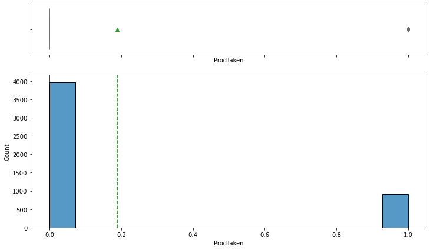

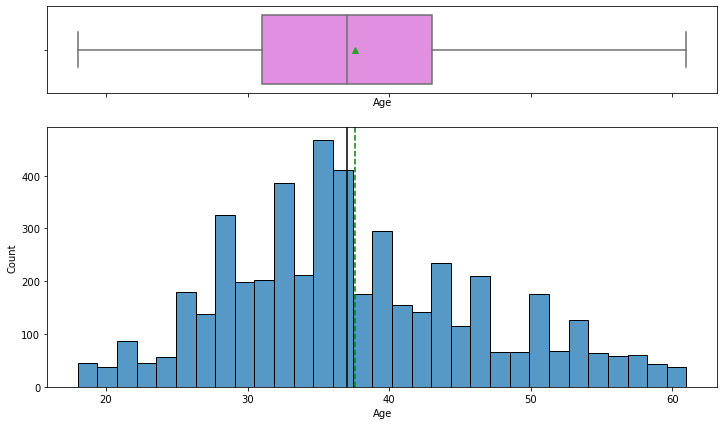

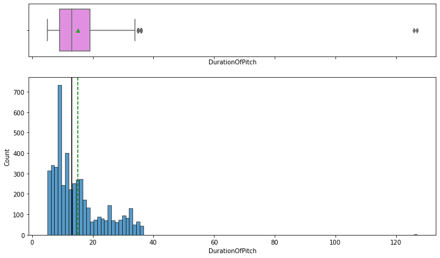

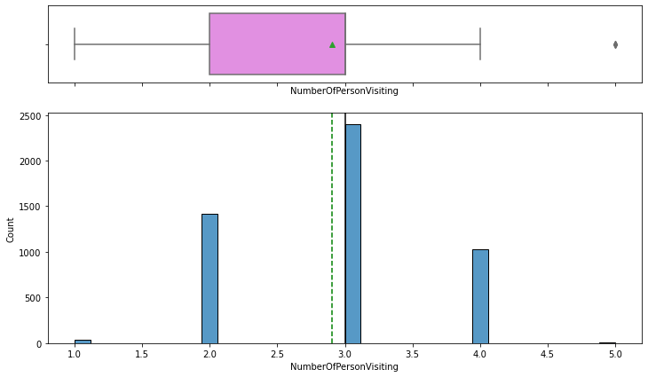

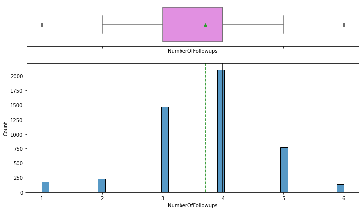

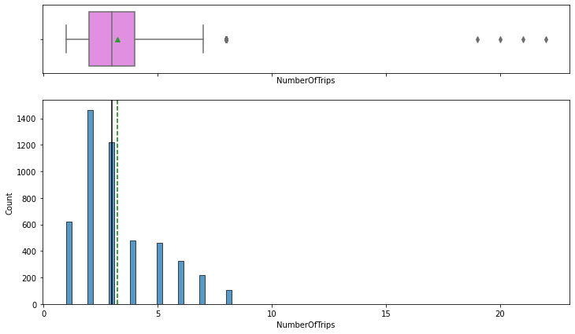

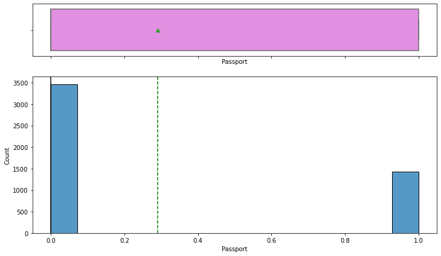

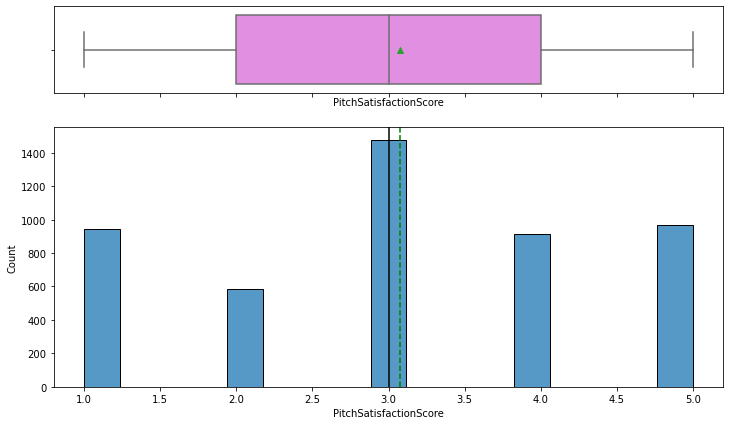

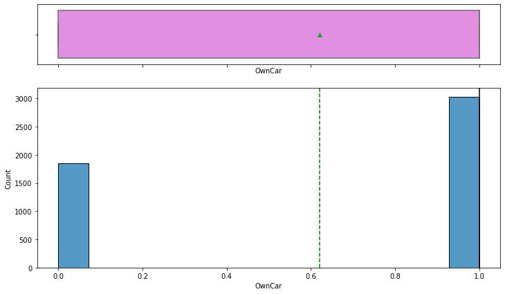

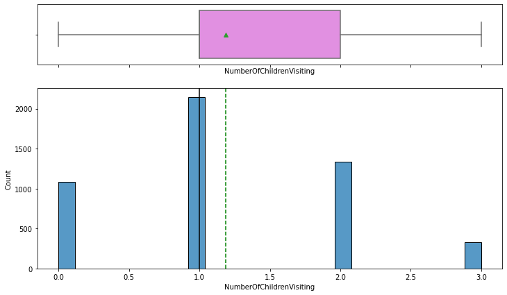

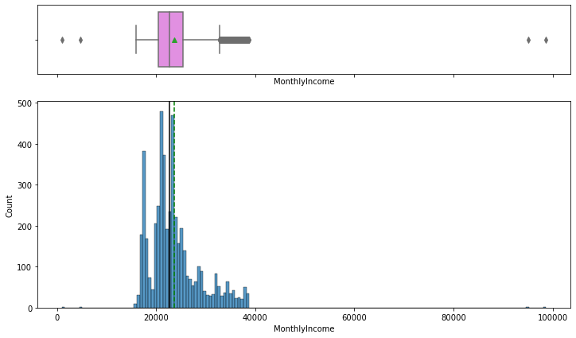

```python
for i in num_vars:
    histogram_boxplot(df[num_vars], i)
```

### Insights

- `ProdTaken` is a boolean value as you can see in the histogram. With this being the variable we want to predict it is important to notice that the data is not balanced. We will want to make sure to stratify the data when we split it later.
- `Age` has a decently centered distribution as you can see the mean and median are very close to each other.
- `DurationOfPitch` is skewed to the right with a few outlier. This makes sense, generally, a pitch is going to be shorter.
- `NumberOfPersonVisiting` is also centrally distrubted with the most number of people visiting is 3. At first, I thought this was interesting, I would have thought it would have been 2 as in a couple. But then, I saw further down in the `NumberOfChildrenVisiting` that it was most common to bring 1 child which would be a couple plus 1.
- The most common `NumberOfFollowups` was 4.
- `NumberOfTrips` is skewed to the right, which again makes sense because it is more common for people to go on less trips than more with the most common number being 2 trips.
- `Passport` is another boolean values with 0 meaning the person does not have a passport. Here we can see that more people do not have a passport than do.
- `PitchSatisfactionScore` appears to be a rating system from 1 to 5. I did go back an forth about whether I should change this and a couple other variables to a categorical variable but wanted to see how they reacted in the testing before I made any changes. Here we can see the average pitch score is 3.0
- `OwnCar` is again a boolean value where 0 means the person does not own a car. Here we can see that more people own a car than don't.
- `MonthlyIncome` has a very close mean and median which would generally mean the data is centrally distributed but when you look at the histogram, I would initally say it is right skewed. But after looking at the box plot there are quite a few outliers that are pulling the mean further to the right that it would be if the outliers were take out.

```python
# function to create labeled barplots


def labeled_barplot(data, feature, perc=False, n=None):
    """
    Barplot with percentage at the top

    data: dataframe
    feature: dataframe column
    perc: whether to display percentages instead of count (default is False)
    n: displays the top n category levels (default is None, i.e., display all levels)
    """

    total = len(data[feature])  # length of the column
    count = data[feature].nunique()
    if n is None:
        plt.figure(figsize=(count + 1, 5))
    else:
        plt.figure(figsize=(n + 1, 5))

    plt.xticks(rotation=90, fontsize=15)
    ax = sns.countplot(
        data=data,
        x=feature,
        palette="Paired",
        order=data[feature].value_counts().index[:n].sort_values(),
    )

    for p in ax.patches:
        if perc == True:
            label = "{:.1f}%".format(
                100 * p.get_height() / total
            )  # percentage of each class of the category
        else:
            label = p.get_height()  # count of each level of the category

        x = p.get_x() + p.get_width() / 2  # width of the plot
        y = p.get_height()  # height of the plot

        ax.annotate(
            label,
            (x, y),
            ha="center",
            va="center",
            size=12,
            xytext=(0, 5),
            textcoords="offset points",
        )  # annotate the percentage

    plt.show()  # show the plot
```

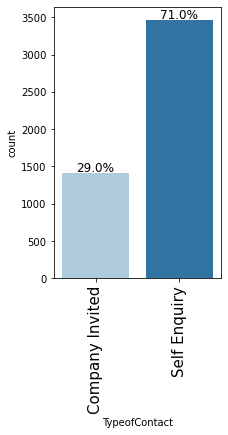

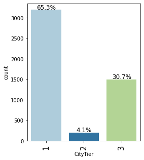

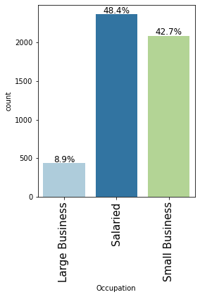

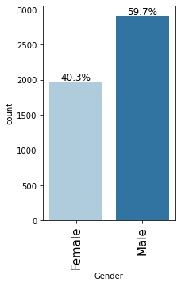

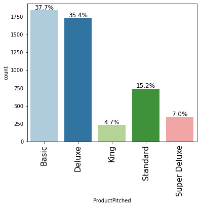

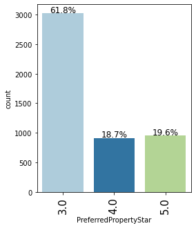

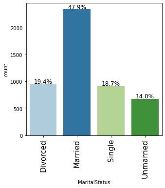

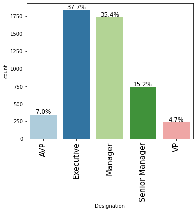

```python
for i in cat_vars:
    labeled_barplot(df, i, perc=True)
```

### Bivariate analysis

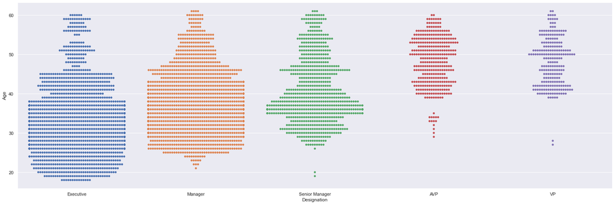

```python
ordered_designation = ["Executive", "Manager", "Senior Manager", "AVP", "VP"]
sns.set(rc={"figure.figsize": (21, 7)})
sns.catplot(
    x="Designation",
    y="Age",
    kind="swarm",
    data=df,
    height=7,
    aspect=3,
    order=ordered_designation,
)
```

- This swarm plot really shows that the Executive Designation is occupied by the youngest people.
- VP is the Designation that is least populated.
- As I think of creating a customer profile this swarm plot allows me to see the age population in each designation with the order starting at youngest being: Executive, Manager, Senior Manager, AVP, and VP.

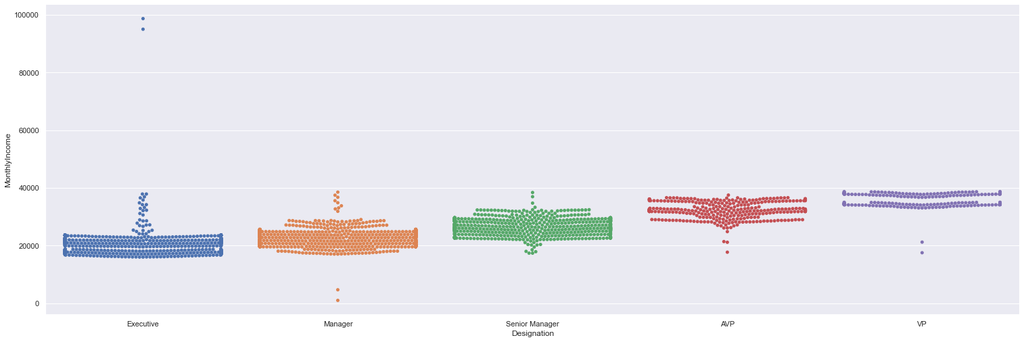

```python
sns.set(rc={"figure.figsize": (21, 7)})
sns.catplot(
    x="Designation",
    y="MonthlyIncome",
    kind="swarm",
    data=df,
    height=7,
    aspect=3,
    order=ordered_designation,
)
```

```python
MI_stats = df.groupby("Designation").agg({"MonthlyIncome": ["mean", "min", "max"]})

print("Mean, min, and max values of Monthly Income by Designation")
print(MI_stats)
```

```
Mean, min, and max values of Monthly Income by Designation
               MonthlyIncome
                        mean      min      max
Designation
AVP             32241.046784  17705.0  37502.0
Executive       20113.730157  16009.0  98678.0
Manager         22725.488510   1000.0  38525.0
Senior Manager  26637.749326  17372.0  38395.0
VP              35878.947826  17517.0  38677.0
```

- I wanted to further explore the idea of Executive being the lowest Designation by income.
- This swarm plot shows that Executive, Manager, and Senior Manager are all pretty compacted. However, AVP and VP have a few noticable shelves of income.
- The order of Designation is correct.
- I do believe that the outliers for the Executive Designation are wrong. I do not know how someone in an Executive Designation would make more than a VP. I feel the 9 was mistaken and should have been a 3. However, I do not have significant proof and want to wait before I make changes to the data.

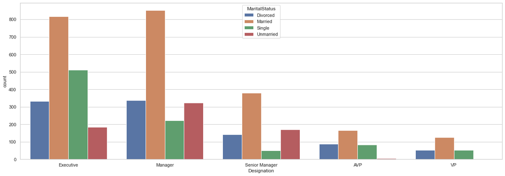

```python
sns.set_theme(style="whitegrid")
sns.countplot(data=df, x="Designation", hue="MaritalStatus", order=ordered_designation)
```

```python
df.groupby(["Designation", "MaritalStatus"]).size()
```

```
Designation     MaritalStatus
AVP             Divorced          88
                Married          166
                Single            82
                Unmarried          6
Executive       Divorced         332
                Married          816
                Single           511
                Unmarried        183
Manager         Divorced         336
                Married          852
                Single           221
                Unmarried        323
Senior Manager  Divorced         142
                Married          380
                Single            50
                Unmarried        170
VP              Divorced          52
                Married          126
                Single            52
                Unmarried          0
dtype: int64
```

```python
e = 332 + 816 + 511 + 183
m = 336 + 852 + 221 + 323
sm = 142 + 380 + 50 + 170
avp = 88 + 166 + 82 + 6
vp = 52 + 126 + 52
ldf = len(df)
print(e, m, sm, avp, vp)
print(e / ldf, m / ldf, sm / ldf, avp / ldf, vp / ldf)
```

```
1842 1732 742 342 230
0.37684124386252044 0.35433715220949263 0.15180032733224222 0.06996726677577741 0.04705400981996727
```